# #1 PBN Experiment steps for processing

01 octubre 2022

### #1 Processing steps

#### Perform the simulation

For each flight simulation, “Flightapp” generates 3 tables:

- flight (position, speed, etc.)
- actions (control actions performed by the pilot)
- imquery (information checks performed by the pilot)

#### Discretize simulation tables

- For each flight, “PostFlight” generates 1 table (ending with “dis”), and we export as CSV for processing with R.
- All CSV flights need to be stored in a specific folder of the R path (“csv_in/”).

#### Create “big” dataset in R

Using the function “createInfoDF”, that returns a list of dataframes, we obtain the dataset with all flights and the initial variables. Useless rows are discarded in this step.

#### The “flights_info” table

We also obtain a dataframe with a summary of the dataset, we call it “flights_info”:

| id | disTable | initialRows | firstIndex | lastIndex | deviationfirstIndex | deviationlastIndex | deviationexceeded | deviationmax | deviationmean |
| --- | --- | --- | --- | --- | --- | --- | --- | --- | --- |
| 1 | 20220121223209dis | 1977 | 1 | 1930 | 0.0004094 | 0.3090253 | 0.0000000 | 0.9809517 | 0.3187659 |
| 2 | 20220121230742dis | 1949 | 1 | 1917 | 0.0002194 | 0.0529804 | 0.8868023 | 1.0245125 | 0.2287594 |
| 3 | 20220123194045dis | 1996 | 1 | 1917 | 0.0004871 | 0.2986273 | 0.0000000 | 0.6667019 | 0.1708445 |
| 4 | 20220125113713dis | 1962 | 1 | 1919 | 0.0005534 | 0.1627686 | 0.0000000 | 0.6390038 | 0.1720996 |
| 5 | 20220316145030dis | 1943 | 1 | 1845 | 0.0003181 | 0.0552582 | 3.1978320 | 1.1774307 | 0.2293945 |
| 6 | 20220316153735dis | 1900 | 1 | 1871 | 0.0003222 | 0.0161252 | 0.0000000 | 0.7176776 | 0.1638964 |
| 7 | 20220512161006dis | 1962 | 1 | 1920 | 0.0005859 | 0.3391114 | 0.0000000 | 0.8794430 | 0.2712950 |
| 8 | 20220523212158dis | 1911 | 1 | 1890 | 0.0003100 | 0.0162455 | 0.0000000 | 0.8161311 | 0.1295424 |
| 9 | 20220524203226dis | 1938 | 1 | 1904 | 0.0003080 | 0.0277673 | 0.0000000 | 0.7762082 | 0.1418865 |
| 10 | 20220527110631dis | 1934 | 1 | 1896 | 0.0004087 | 0.1945740 | 0.0000000 | 0.5697111 | 0.1893888 |
| 11 | 20220528112722dis | 1917 | 1 | 1888 | 0.0004087 | 0.0203251 | 1.9597458 | 1.0638933 | 0.1926771 |
| 12 | 20220529142028dis | 1905 | 1 | 1877 | 0.0003161 | 0.0143047 | 0.0000000 | 0.7765556 | 0.1639485 |
| 13 | 20220530144122dis | 1880 | 1 | 1860 | 0.0004797 | 0.0182252 | 0.0000000 | 0.8486337 | 0.1627407 |
| 14 | 20220531151247dis | 1907 | 1 | 1884 | 0.0003127 | 0.0318930 | 0.0000000 | 0.8364559 | 0.1990694 |
| 15 | 20220601154130dis | 1916 | 1 | 1889 | 0.0002255 | 0.1581891 | 0.0000000 | 0.5939349 | 0.1251029 |
| 16 | 20220602160225dis | 1948 | 1 | 1887 | 0.0003107 | 0.0383346 | 0.0000000 | 0.5766042 | 0.1002377 |
| 17 | 20220603192433dis | 1914 | 1 | 1877 | 0.0004804 | 0.0215958 | 0.0000000 | 0.5849015 | 0.1181386 |
| 18 | 20220604200536dis | 1923 | 1 | 1893 | 0.0003925 | 0.1224819 | 0.0000000 | 0.4652699 | 0.0828084 |
| 19 | 20220906134140dis | 1914 | 1 | 1882 | 0.0003134 | 0.0731759 | 0.0000000 | 0.9665278 | 0.1924313 |
| 20 | 20220906153443dis | 1894 | 1 | 1872 | 0.0004932 | 0.1074852 | 0.0000000 | 0.8681653 | 0.1823608 |
| 21 | 20220906200133dis | 1916 | 1 | 1874 | 0.0003201 | 0.1345631 | 0.0000000 | 0.9313942 | 0.1819750 |
| 22 | 20220907072201dis | 1927 | 1 | 1898 | 0.0002248 | 0.0846236 | 0.0000000 | 0.5042391 | 0.1283485 |

- For each one of the 22 flights, we see the total number of rows and the rows of interest (initialRows, firstIndex, lastIndex), which are kept.
- We also obtain basic statistics of the deviation:
- deviationfirstIndex & deviationlastIndex provide an indication that the flight is acceptable at the beginning and the end.
- deviationexceeded is the percentage of samples where the deviation is bigger than 1NM.
- deviationmax is the maximum deviation within the flight, and deviationmean is the mean.

#### Overview of the flights

This is a map representation of each flight:

##### Flight 1 :

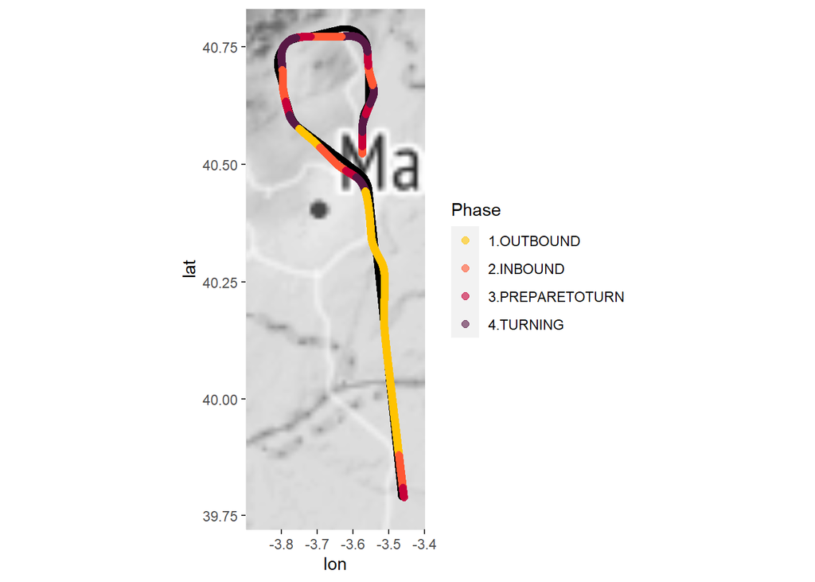

##### Flight 2 :

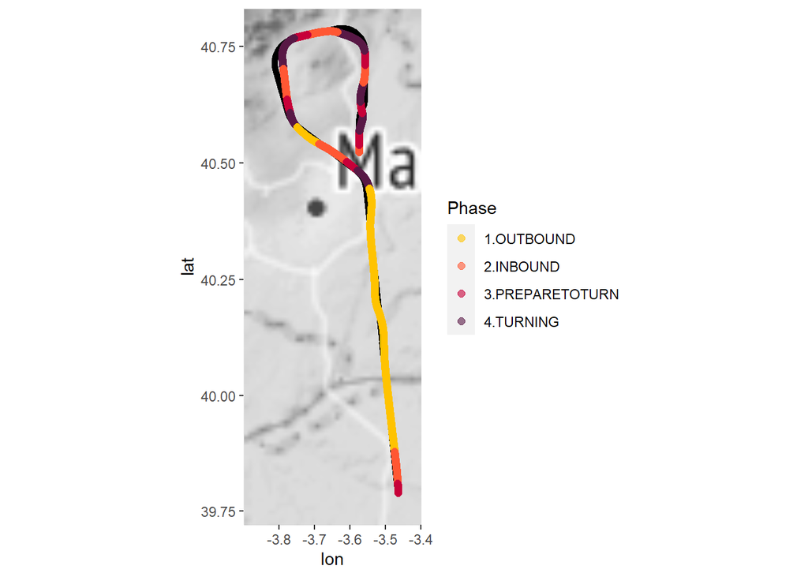

##### Flight 3 :

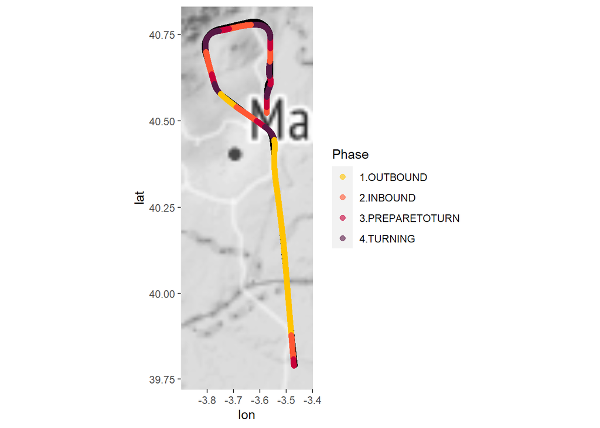

##### Flight 4 :

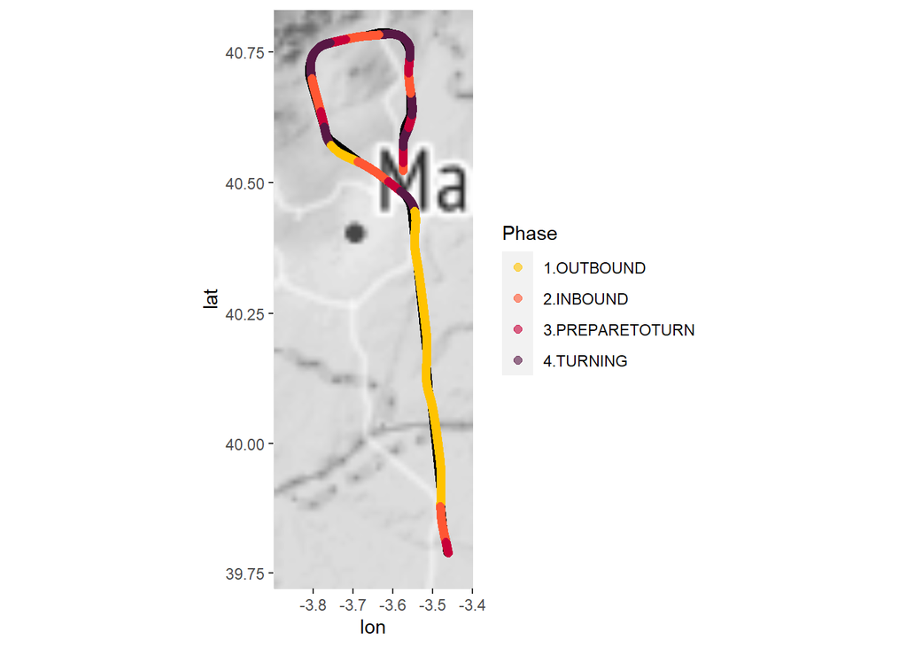

##### Flight 5 :

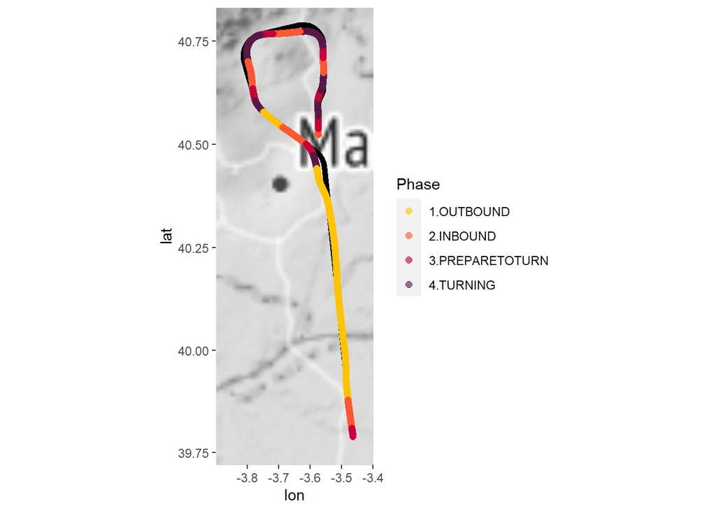

##### Flight 6 :

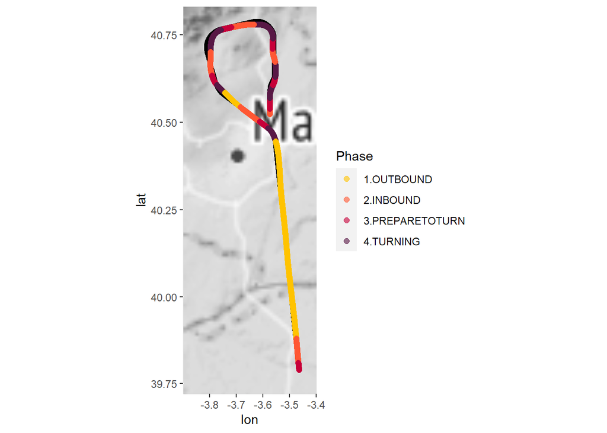

##### Flight 7 :

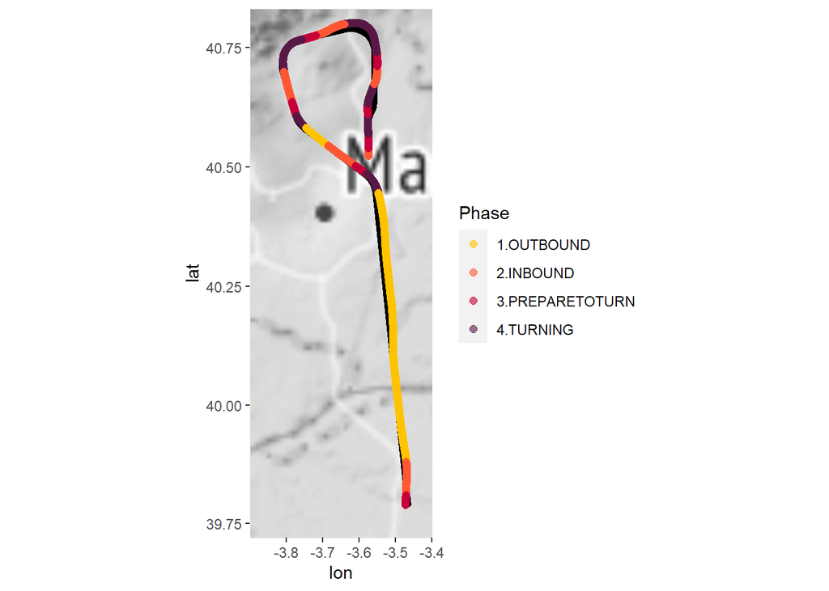

##### Flight 8 :

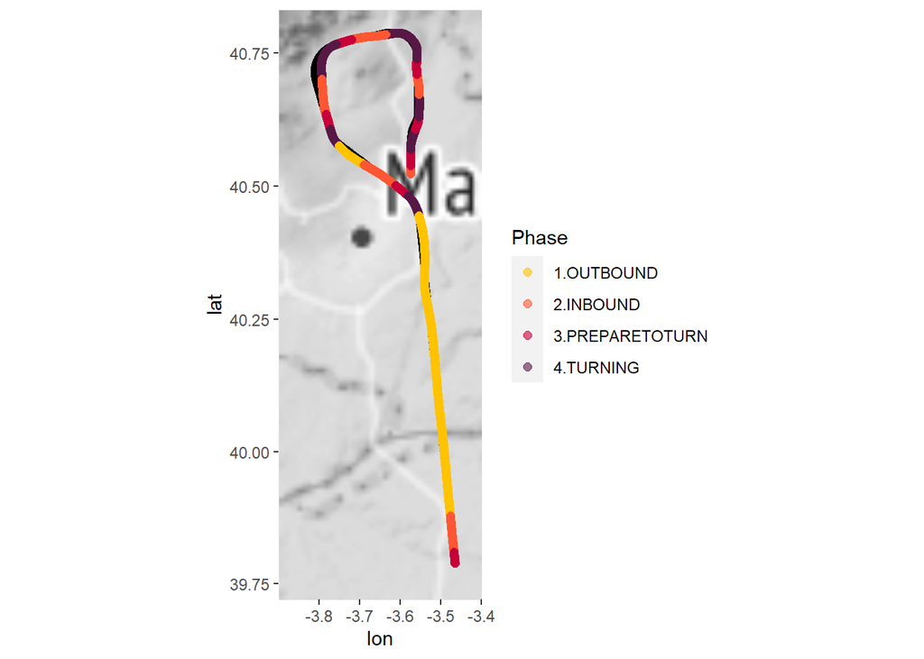

##### Flight 9 :

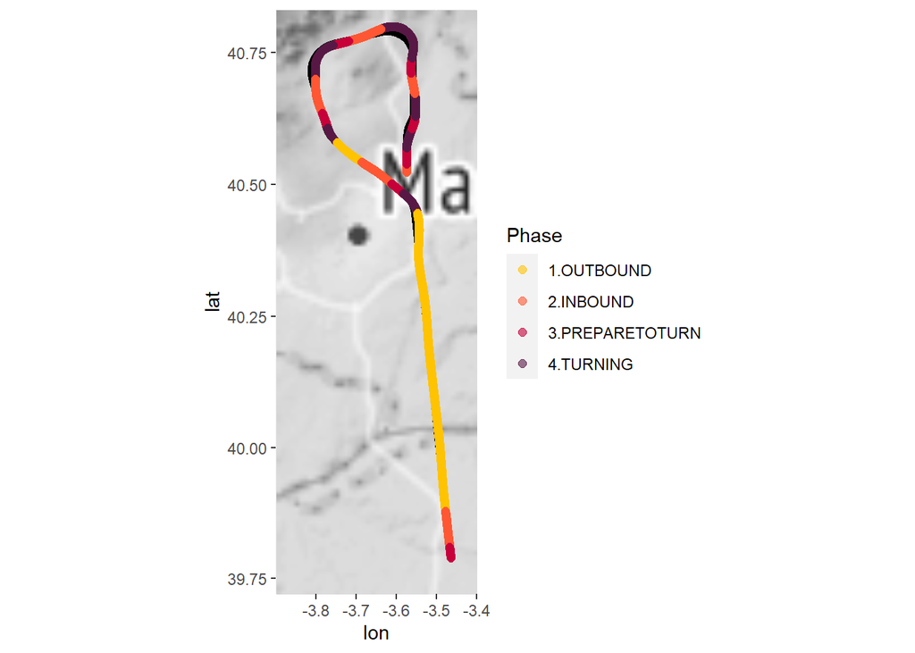

##### Flight 10 :

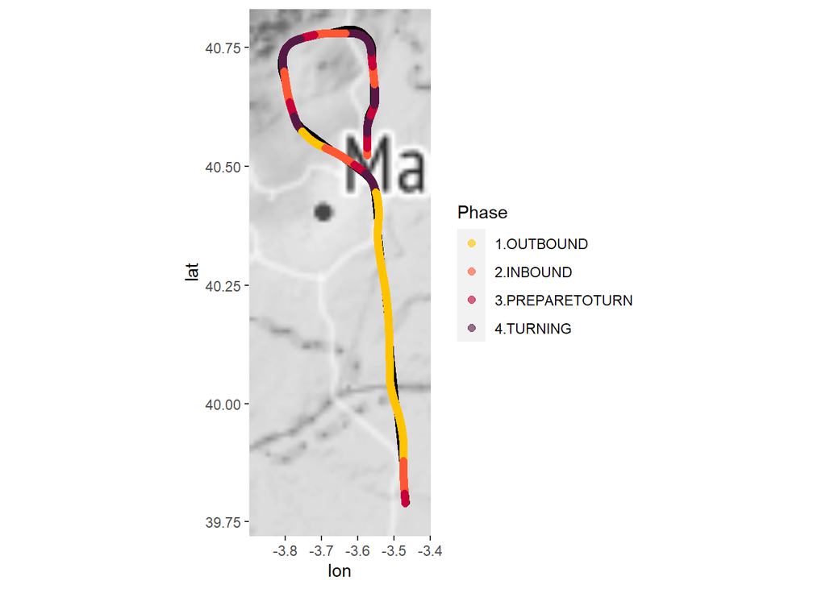

##### Flight 11 :

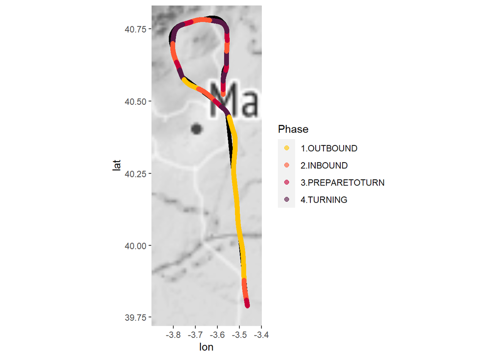

##### Flight 12 :

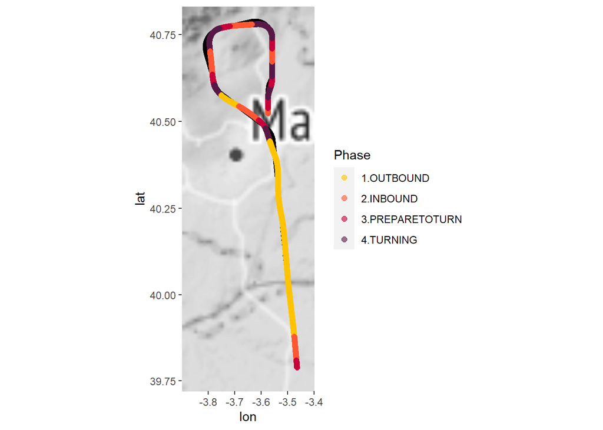

##### Flight 13 :

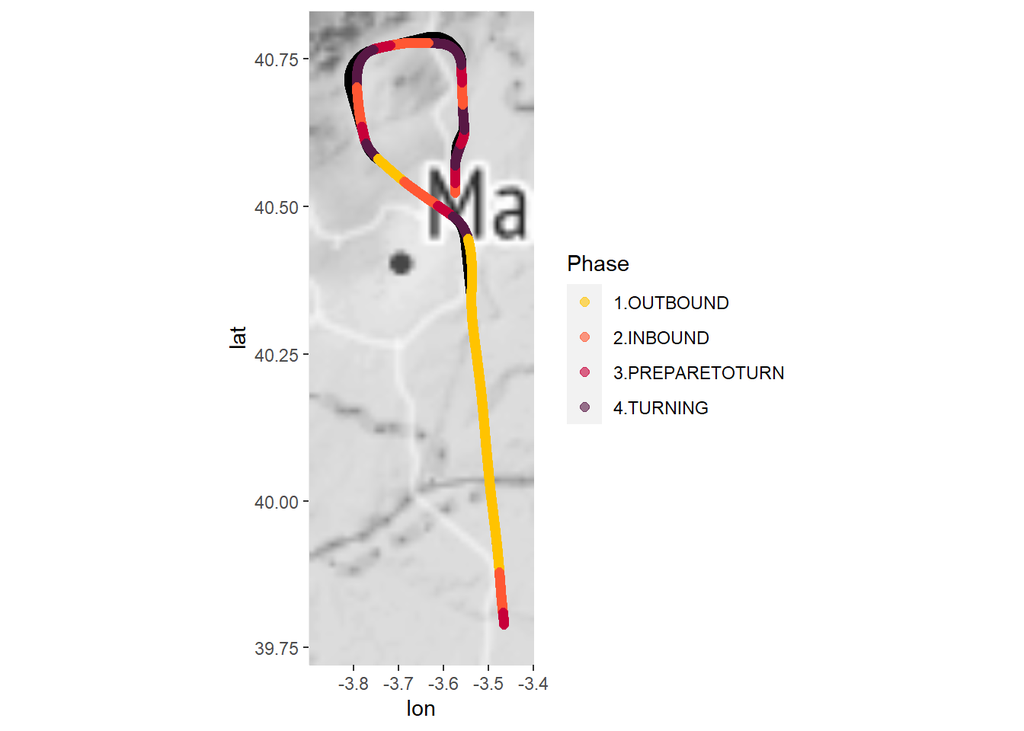

##### Flight 14 :

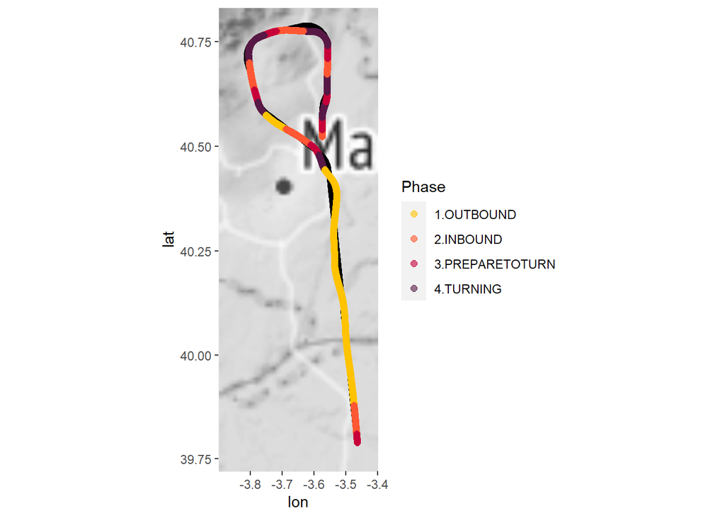

##### Flight 15 :

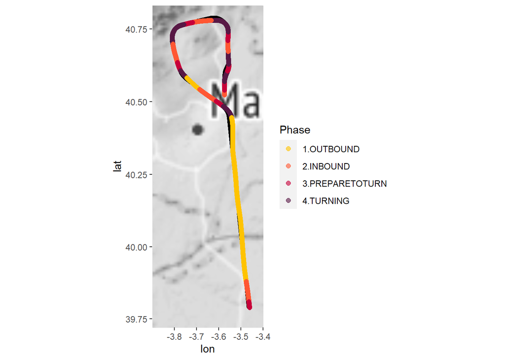

##### Flight 16 :

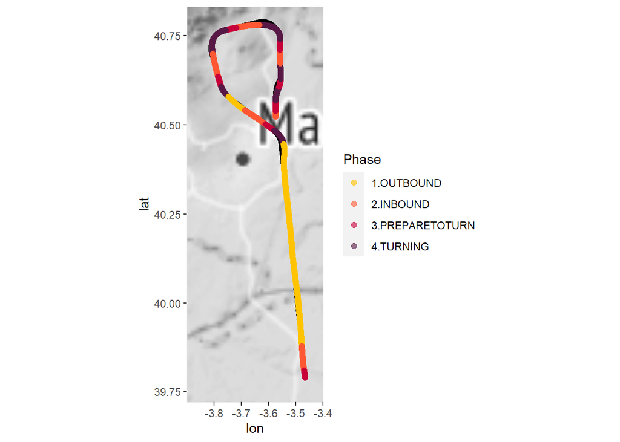

##### Flight 17 :

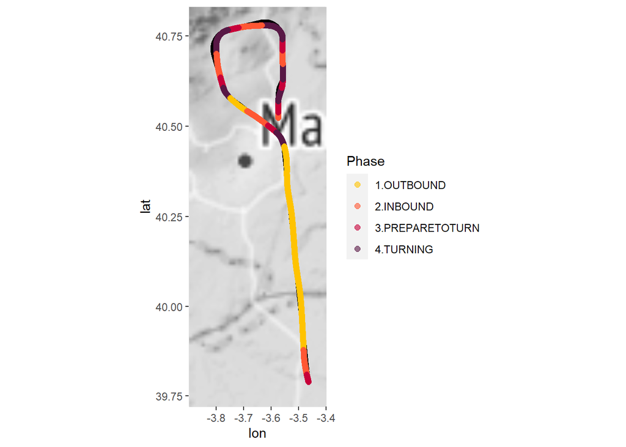

##### Flight 18 :

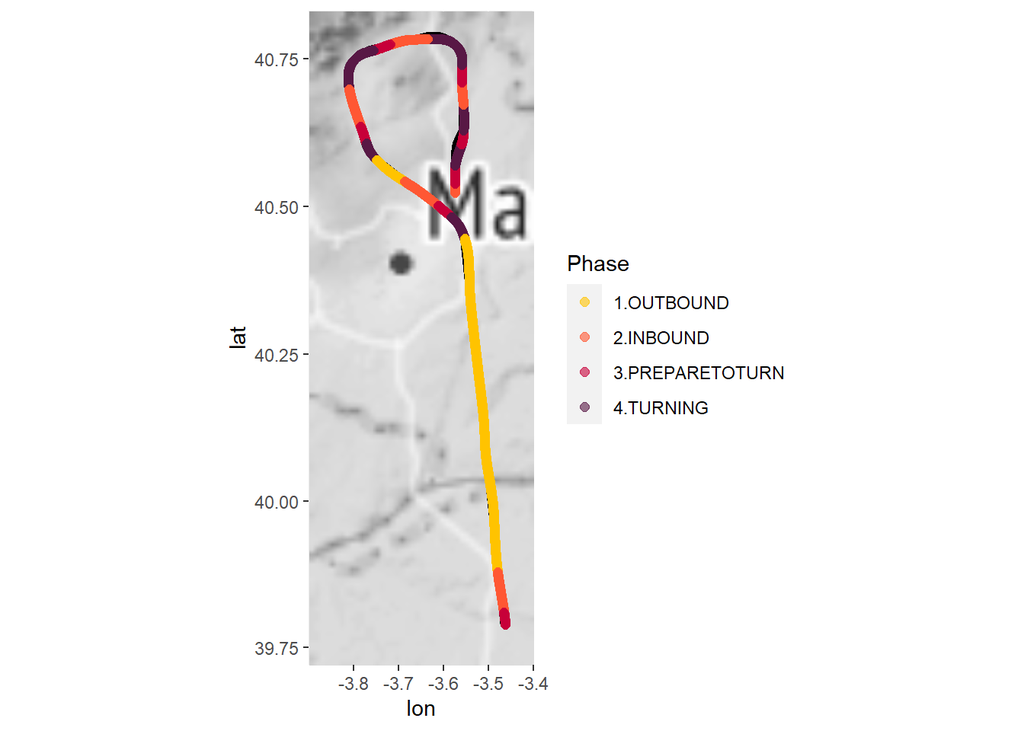

##### Flight 19 :

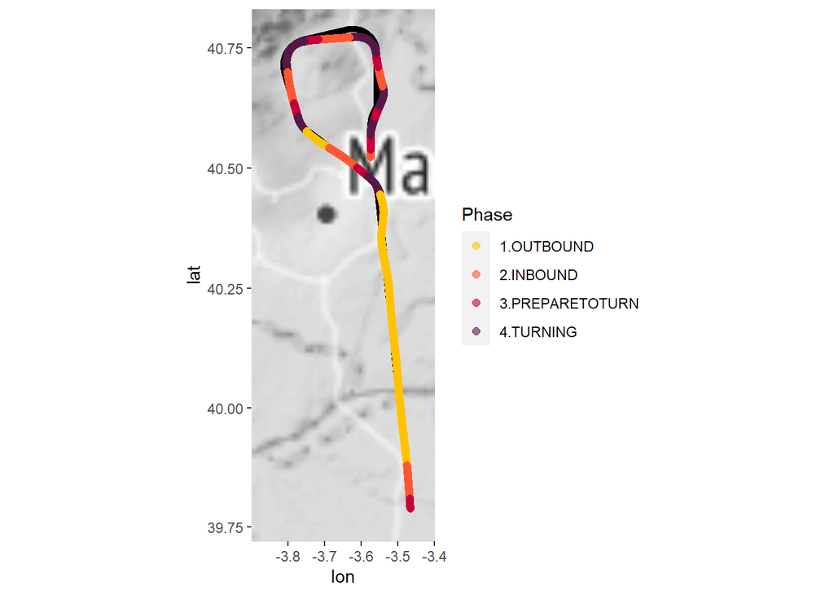

##### Flight 20 :

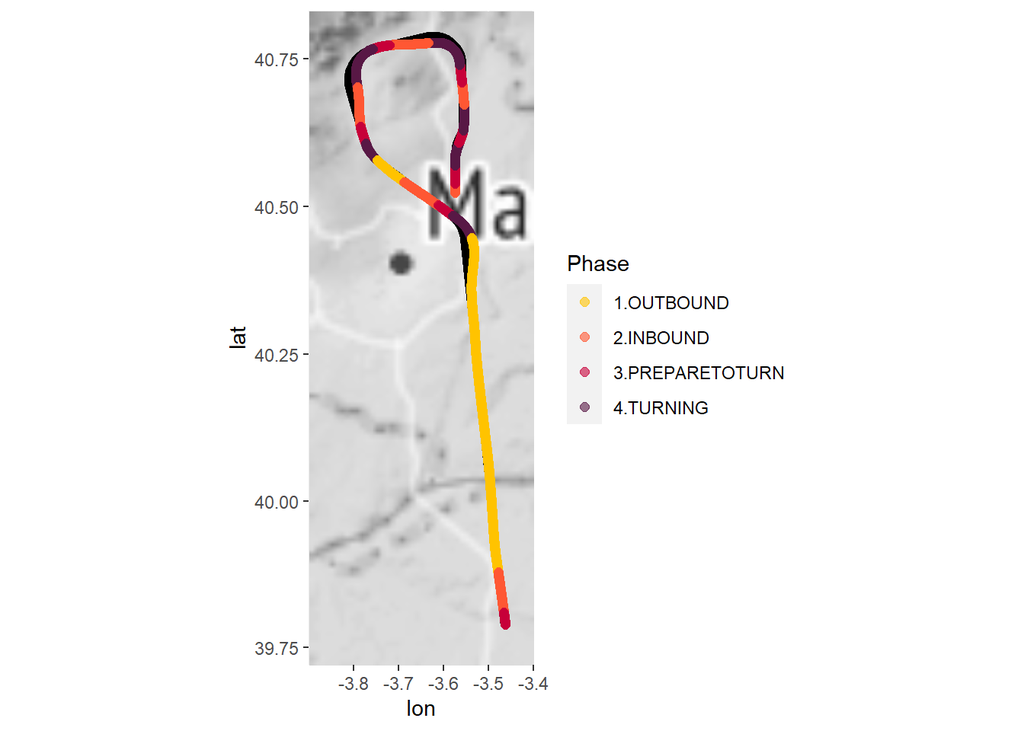

##### Flight 21 :

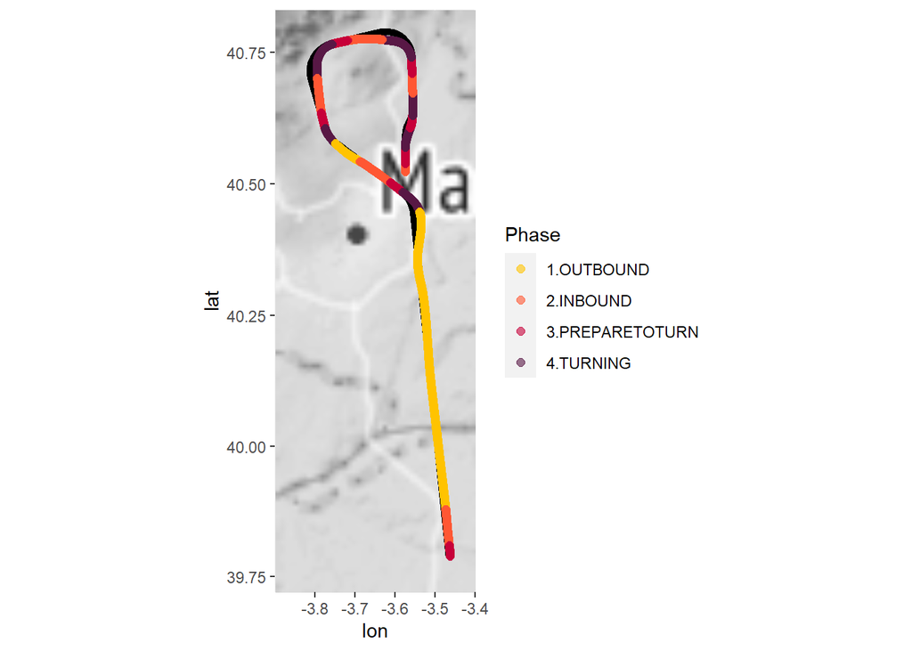

##### Flight 22 :

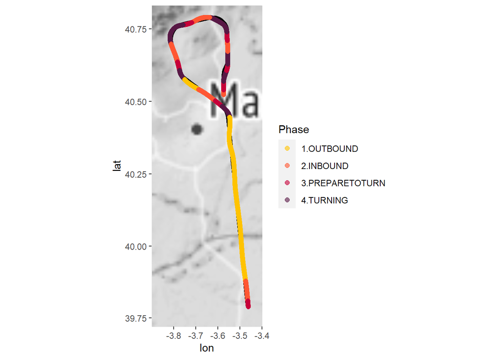